# Practical Machine Learning Project: Human Activity Recognition

Owen Byrne

December 6, 2014

# Executive Summary

Using devices such as Jawbone Up, Nike FuelBand, and Fitbit it is now possible to collect a large amount of data about personal activity relatively inexpensively. These type of devices are part of the quantified self movement - a group of enthusiasts (including the author) who take measurements about themselves regularly to improve their health, to find patterns in their behavior, or because they are tech geeks. One thing that people regularly do is quantify how much of a particular activity they do, but they rarely quantify how well they do it.

The aim of this report was to use data from accelerometers placed on the belt, forearm, arm, and dumbell of six participants to predict how well they were doing the exercise in terms of the classification in the data.

```r
directory <- "data"
training_file <- "training.csv"
testing_file <- "testing.csv"

if (!file.exists(directory)) {
    dir.create(directory)
}

# curl option needed on OSX to access https urls
download.file("https://d396qusza40orc.cloudfront.net/predmachlearn/pml-training.csv", destfile = paste("./", directory, "/", training_file, sep=""), method="curl", quiet=TRUE)
download.file("https://d396qusza40orc.cloudfront.net/predmachlearn/pml-testing.csv", destfile = paste("./", directory, "/", testing_file, sep=""), method="curl", quiet=TRUE)
```

```r
data_training <- read.csv(paste("./", directory, "/", training_file, sep=""), na.strings= c("NA",""," "))
data_training_clean <- data_training[8:length(data_training)]
data_training_NAs <- apply(data_training_clean, 2, function(x) {sum(is.na(x))})
data_training_clean <- data_training_clean[,which(data_training_NAs == 0)]
ncol(data_training_clean)
```

```
## [1] 53
```

The cleaned data was then split into training and cross-validation sets.

```r
inTrain <- createDataPartition(y = data_training_clean$classe, p = 0.7, list = FALSE)
training <- data_training_clean[inTrain, ]
validation <- data_training_clean[-inTrain, ]
```

A random forest model was selected first to predict the classification because it has methods for balancing error in class population unbalanced data sets. One downside is fitting the model was very slow. Because the random forest model was so slow, a second model using boosting was done.

The correlation between any two trees in the forest increases the forest error rate. Therefore, a correllation plot was produced in order to see how strong the variables relationships are with each other (Exhibit 1).

```r
system.time(model1 <- train(classe ~ ., data=training, method="rf"))
```

```
##     user   system  elapsed
## 3328.305   24.965 3362.787
```

```r
model1
```

```
## Random Forest
##
## 13737 samples
##    52 predictor
##     5 classes: 'A', 'B', 'C', 'D', 'E'
##
## No pre-processing
## Resampling: Bootstrapped (25 reps)
##
## Summary of sample sizes: 13737, 13737, 13737, 13737, 13737, 13737, ...
##
## Resampling results across tuning parameters:
##
##   mtry  Accuracy   Kappa      Accuracy SD  Kappa SD
##    2    0.9884234  0.9853569  0.001506388  0.001902628
##   27    0.9878919  0.9846839  0.001510120  0.001914837
##   52    0.9789982  0.9734300  0.005233043  0.006633935
##
## Accuracy was used to select the optimal model using  the largest value.
## The final value used for the model was mtry = 2.
```

```r
system.time(model2 <- train(classe ~ ., data=training, method="gbm", verbose=FALSE))
```

```
##     user   system  elapsed
## 1306.029   15.427 1324.011
```

```r
model2
```

```
## Stochastic Gradient Boosting
##
## 13737 samples
##    52 predictor
##     5 classes: 'A', 'B', 'C', 'D', 'E'
##
## No pre-processing
## Resampling: Bootstrapped (25 reps)
##
## Summary of sample sizes: 13737, 13737, 13737, 13737, 13737, 13737, ...
##
## Resampling results across tuning parameters:
##
##   interaction.depth  n.trees  Accuracy   Kappa      Accuracy SD
##   1                   50      0.7516885  0.6849559  0.006082831
##   1                  100      0.8167121  0.7678856  0.005299926
##   1                  150      0.8503663  0.8105521  0.004244805
##   2                   50      0.8532103  0.8138736  0.004780294
##   2                  100      0.9051417  0.8798850  0.004281871
##   2                  150      0.9285014  0.9094793  0.004406352
##   3                   50      0.8949768  0.8669649  0.004884813
##   3                  100      0.9385820  0.9222423  0.004462452
##   3                  150      0.9555249  0.9437001  0.003803812
##   Kappa SD
##   0.007734458
##   0.006792882
##   0.005419876
##   0.006063825
##   0.005414314
##   0.005552784
##   0.006193855
##   0.005644958
##   0.004819964
##
## Tuning parameter 'shrinkage' was held constant at a value of 0.1
## Accuracy was used to select the optimal model using  the largest value.
## The final values used for the model were n.trees = 150,
##  interaction.depth = 3 and shrinkage = 0.1.
```

## Cross-validation

```r
predictRFCrossVal1 <- predict(model1, validation)
confusionMatrix(validation$classe, predictRFCrossVal1)
```

```
## Confusion Matrix and Statistics
##
##           Reference
## Prediction    A    B    C    D    E
##          A 1670    4    0    0    0
##          B    3 1130    6    0    0
##          C    0    4 1020    2    0
##          D    0    0   25  939    0
##          E    0    0    0    7 1075
##
## Overall Statistics
##
##                Accuracy : 0.9913
##                  95% CI : (0.9886, 0.9935)
##     No Information Rate : 0.2843
##     P-Value [Acc > NIR] : < 2.2e-16
##
##                   Kappa : 0.989
##  Mcnemar's Test P-Value : NA
##
## Statistics by Class:
##
##                      Class: A Class: B Class: C Class: D Class: E
## Sensitivity            0.9982   0.9930   0.9705   0.9905   1.0000
## Specificity            0.9991   0.9981   0.9988   0.9949   0.9985
## Pos Pred Value         0.9976   0.9921   0.9942   0.9741   0.9935
## Neg Pred Value         0.9993   0.9983   0.9936   0.9982   1.0000
## Prevalence             0.2843   0.1934   0.1786   0.1611   0.1827
## Detection Rate         0.2838   0.1920   0.1733   0.1596   0.1827
## Detection Prevalence   0.2845   0.1935   0.1743   0.1638   0.1839
## Balanced Accuracy      0.9986   0.9955   0.9846   0.9927   0.9993
```

```r
predictRFCrossVal2 <- predict(model2, validation)
confusionMatrix(validation$classe, predictRFCrossVal2)
```

```
## Confusion Matrix and Statistics
##
##           Reference
## Prediction    A    B    C    D    E
##          A 1645   15    8    5    1
##          B   28 1070   39    2    0
##          C    0   23  990   13    0
##          D    2    4   31  918    9
##          E    3   16    8   14 1041
##
## Overall Statistics
##
##                Accuracy : 0.9624
##                  95% CI : (0.9573, 0.9672)
##     No Information Rate : 0.2851
##     P-Value [Acc > NIR] : < 2.2e-16
##
##                   Kappa : 0.9525
##  Mcnemar's Test P-Value : 1.435e-07
##
## Statistics by Class:
##
##                      Class: A Class: B Class: C Class: D Class: E
## Sensitivity            0.9803   0.9486   0.9201   0.9643   0.9905
## Specificity            0.9931   0.9855   0.9925   0.9907   0.9915
## Pos Pred Value         0.9827   0.9394   0.9649   0.9523   0.9621
## Neg Pred Value         0.9922   0.9878   0.9823   0.9931   0.9979
## Prevalence             0.2851   0.1917   0.1828   0.1618   0.1786
## Detection Rate         0.2795   0.1818   0.1682   0.1560   0.1769
## Detection Prevalence   0.2845   0.1935   0.1743   0.1638   0.1839
## Balanced Accuracy      0.9867   0.9670   0.9563   0.9775   0.9910
```

## Predictions

Finally, the testing set was loaded into R, the same cleaning was done, and the two models applied to classify the test set.

```r
# apply the same treatment to the final testing data
data_test <- read.csv(paste("./", directory, "/", testing_file, sep=""), na.strings= c("NA",""," "))
data_test_NAs <- apply(data_test, 2, function(x) {sum(is.na(x))})
data_test_clean <- data_test[,which(data_test_NAs == 0)]
data_test_clean <- data_test_clean[8:length(data_test_clean)]

# predict the classes of the test set
answers1 <- predict(model1, data_test_clean)
answers1
```

```
##  [1] B A B A A E D B A A B C B A E E A B B B
## Levels: A B C D E
```

```r
answers2 <- predict(model2, data_test_clean)
answers2
```

```
##  [1] B A B A A E D B A A B C B A E E A B B B
## Levels: A B C D E
```

## Conclusion

# Exhibit 1

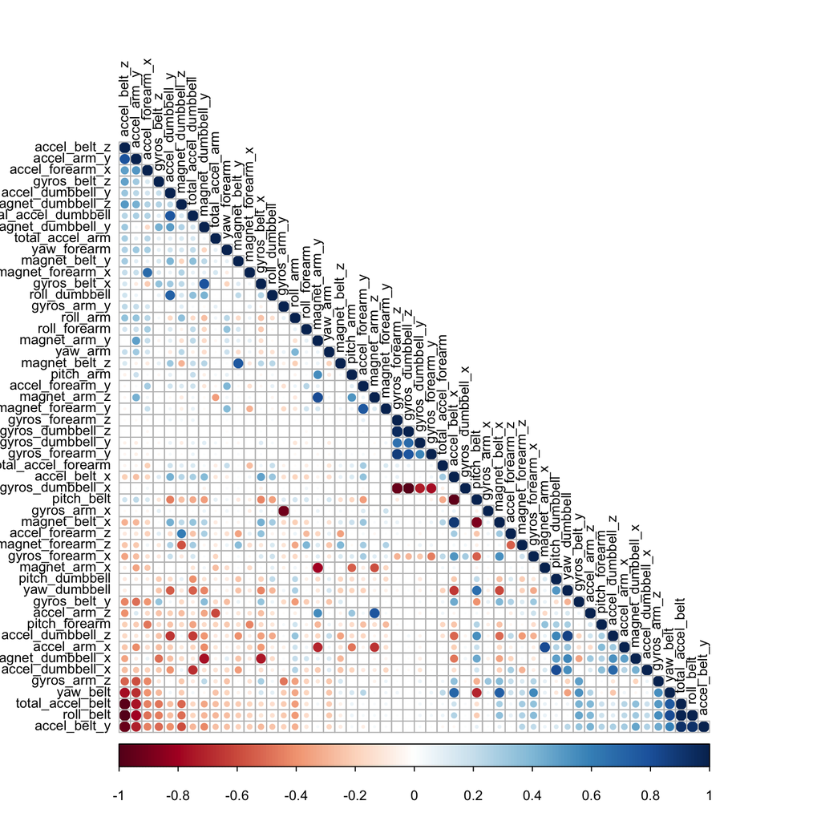

```r
correlMatrix <- cor(training[, -length(training)])
corrplot(correlMatrix, order = "FPC", method = "circle", type = "lower", tl.cex = 0.8,  tl.col = rgb(0, 0, 0))
```